# Frameworks for Inference

Last updated: 2017-02-04

## Notes

## Readings

## Remember the Goal of Statistics

> "a way of taming **uncertainty**, of turning raw **data** into arguments that can resolve profound questions" (Amabile 1989)
- Success depends on evaluating the relative support for different models

## Models?

## Example: Wing Dimorphic Crickets

> Do long-winged crickets have a higher resting metabolic rate than short-winged crickets?

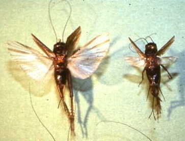

Controlling for body mass,

- Metabolic rates do not differ
- Average metabolic rate of long-wings is higher
- Average metabolic rate of long-wings is lower

## Example: Genetics of Corn Oil Content

> Which set of loci best predicts oil content in corn kernels?

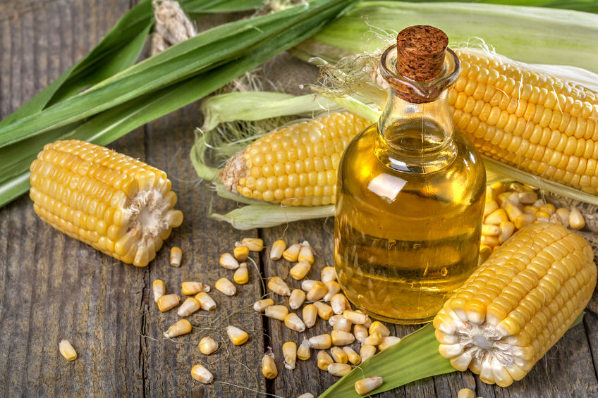

- Heritability of corn oil content is 0
- Different possible combinations of SNPs
- All additive
- Dominance
- Epistasis
- Structural variants

## Example: Canid relationships

> What are the phylogenetic relationships between dog breeds & other canids?

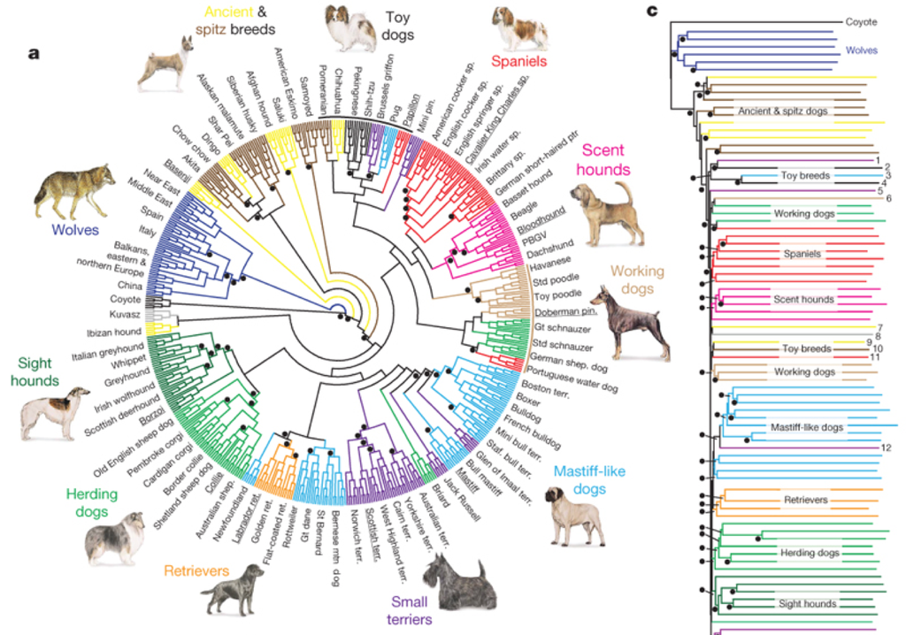

- Star phylogeny
- Single origin of dogs
- Ancient breeds are monophyletic
- Every possible tree….

## Example: Predict the species of a new fossil

> Is this bone more like a chimpanzee, australopith, Neandertal, or modern human?

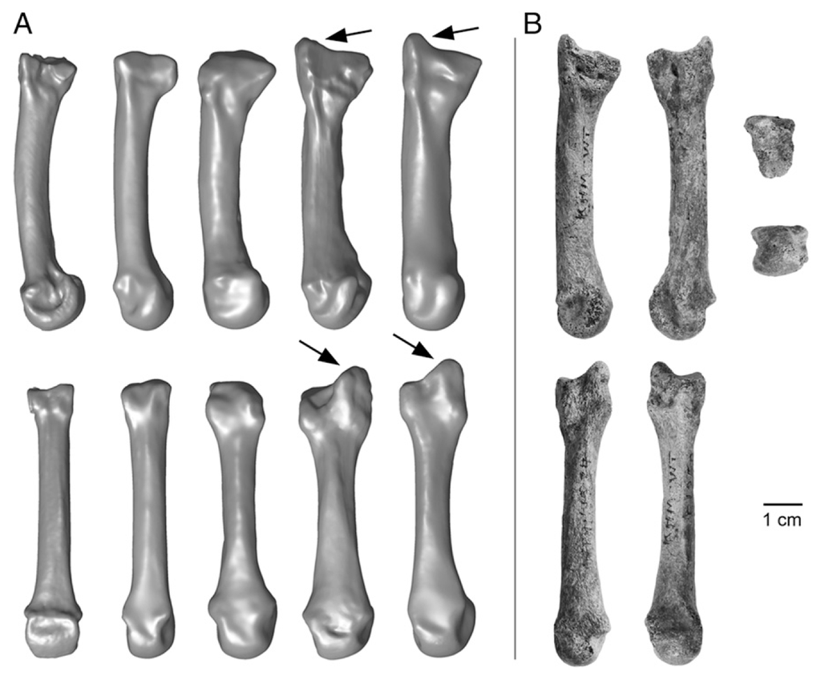

- Relative probabilities of new fossil being in one of four groups
- What is the percent correct classification of known fossils?

## Example: What is the best model for growth in Alligators?

> Do alligators exhibit determinate or indeterminate growth and does growth depend of atmospheric oxygen levels?

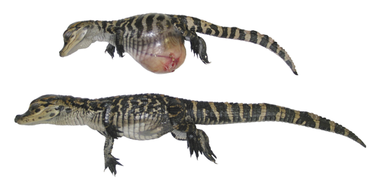

Determinate:

- von Bertalanffy
- Logistic

Indeterminate:

- Polynomial

## Example: What is the best model for growth in Alligators?

von Bertalanffy:

\[Femoral~Length\left(Age\right) = \theta_1 \left(1 - e^{-\theta_2 \left(Age - \theta_3\right)}\right)\]

Logistic:

\[Femoral~Length\left(Age\right) = \frac{\theta_1}{1 + e^{\frac{\theta_2 - Age}{\theta_3}}}\]

Polynomial:

\[Femoral~Length\left(Age\right) = a + b \cdot Age + c \cdot Age^2\]

## Example: What is the best model for growth in Alligators?

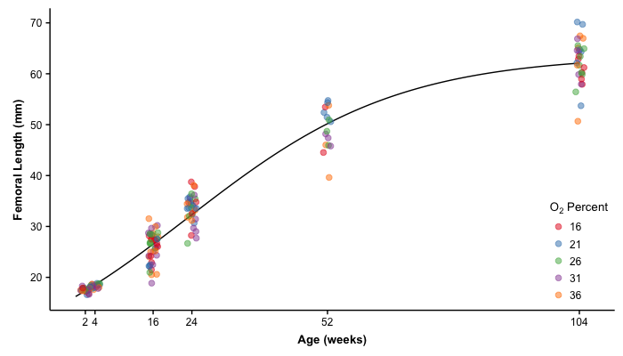

## Example: Your Research

> Your Question Here?

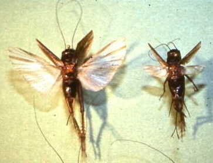

- Model 1
- Model 2
- Model 3

## References

Amabile, T. 1989. Against All Odds Inside Statistics. Annenberg/CPB Collection; Intellimation [distributor].